# notebook_Rise and Fall of Programming Languages

Pierre-Etienne TOULEMONDE

2022-12-10

# 1 Programming Languages study

Tags: Data manipulation, Data visualization, Importing & cleaning data

Principal packages:: tidyverse.

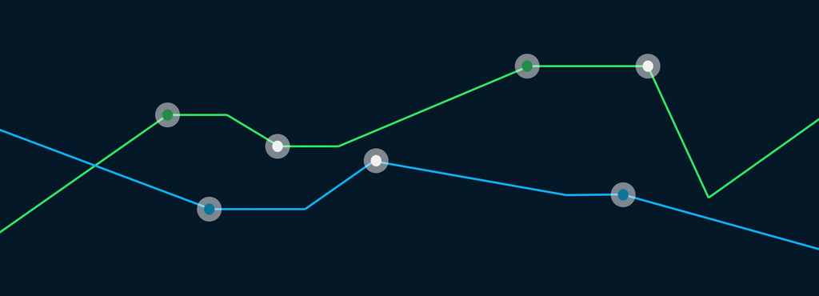

It’s important to stay informed about trends in programming languages and technologies. Knowing what languages are growing or shrinking can help you decide where to invest. An excellent source to gain a better understanding of popular technologies is [Stack Overflow](https://stackoverflow.com/). Stack overflow is an online question-and-answer site for coding topics. By looking at the number of questions about each technology, you can get an idea of how many people are using it. The dataset has been uploaded to the [Stack Exchange site](https://data.stackexchange.com/). Below is an overview of the data that is available to you:

**datasets/stack_overflow_data.csv**

- **year:** The year the question was asked.
- **tag:** A word or phrase that describes the topic of the question.
- **number:** The number of questions with a certain tag in that year.
- **year_total:** The total number of questions asked in that year.

From there, the aim is to explore and manipulate existing data to answer these questions:

1. What fraction of the total number of questions asked in 2019 had the tag R?
2. What were the five most asked tags over the last 5 years (2015-2020)?

## 1.1 Data description

```r
# ---------- 0. Package importation ----------
# install.packages("librarian")
librarian::shelf(tidyverse, skimr, quiet = TRUE)

# ---------- 1. Data collection ----------
df_stack_overflow <- read.csv("datasets/stack_overflow_data.csv")
```

### 1.1.1 stack_overflow dataset

```r
# ---------- 2. Data exploration ----------
print(data.frame(
  Variables = c("Number of lines",
               "Nombre de columns",
               "Nombre de continuous columns",
               "Nombre de discretous variables",
               "Memory allocation"),
  df_stack_overflow = c(nrow(df_stack_overflow),
                  ncol(df_stack_overflow),
                  length(select_if(df_stack_overflow,is.numeric)),
                  length(select(df_stack_overflow, -names(select_if(df_stack_overflow, is.numeric) ) ) ),
                  paste(as.character(round(object.size(df_stack_overflow)/1024), 2), "kb") ) ) )
```

```
##                        Variables df_stack_overflow
## 1                Number of lines            420066
## 2              Nombre de columns                 4
## 3   Nombre de continuous columns                 3
## 4 Nombre de discretous variables                 1
## 5              Memory allocation          12011 kb
```

```r
head(df_stack_overflow, n = 10)
```

```
##    year                 tag number year_total
## 1  2008            treeview     69     168541
## 2  2008     scheduled-tasks     30     168541
## 3  2008      specifications     21     168541
## 4  2008           rendering     35     168541
## 5  2008           http-post      6     168541
## 6  2008       static-assert      1     168541
## 7  2008        asp.net-ajax    159     168541
## 8  2008 collision-detection     10     168541
## 9  2008             systray      4     168541
## 10 2008         html-helper     20     168541
```

About missing data :

```r
print(data.frame(variables = names(df_stack_overflow),
                 n_NA = apply(df_stack_overflow, 2, function(.x) {sum(is.na(.x) )} ),
                 percent_NA = apply(df_stack_overflow, 2,
                                    function(.x) { paste(round(sum(is.na(.x) ) /
                                                                 nrow(df_stack_overflow) * 100, 2) , "%") } ) ) )
```

```
##             variables n_NA percent_NA
## year             year    0        0 %
## tag               tag    0        0 %
## number         number    0        0 %
## year_total year_total    0        0 %
```

#### 1.1.1.1 Graphic description

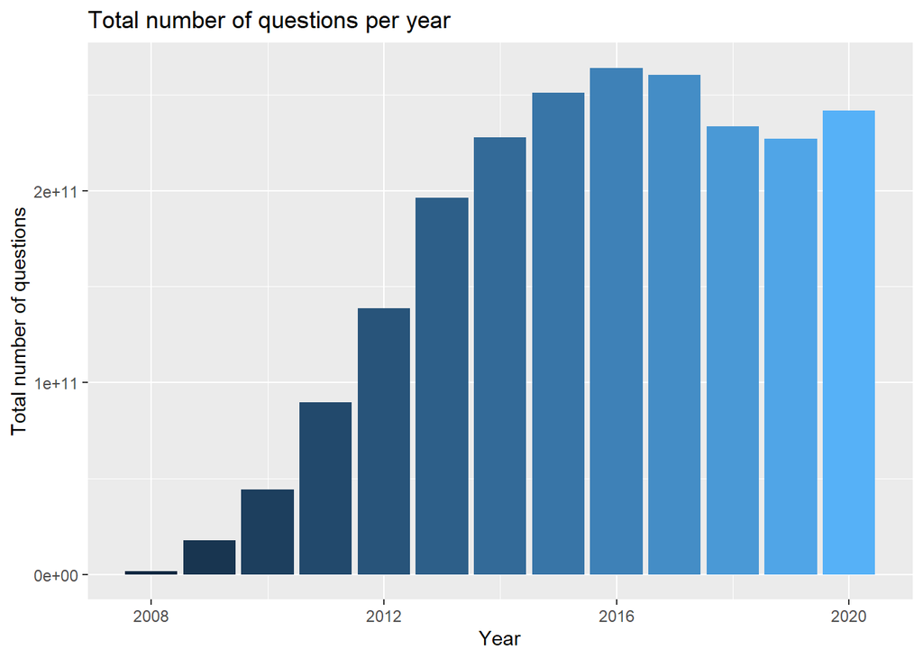

```r
df_stack_overflow %>%
  ggplot(aes(year, y = year_total, fill = year)) +
    geom_col() +
    theme(legend.position = "none") +
    labs(x = "Year",
         y = "Total number of questions",
         title = "Total number of questions per year")
```

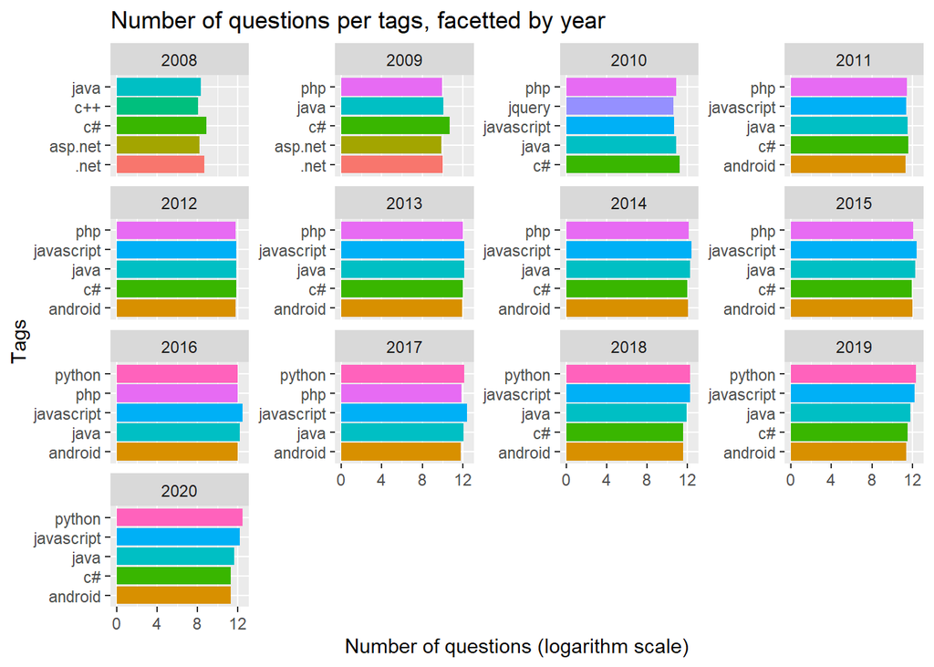

```r
df_stack_overflow %>%
  group_by(year) %>%
  arrange(desc(number)) %>%
  slice_max(number, n = 5) %>%
  ggplot( aes(y = tag, x = log(number), fill = tag)) +
    geom_col(position = position_dodge2() ) +
    facet_wrap(~year, scales="free_y") +
    theme(legend.position="none") +
  labs(x = "Number of questions (logarithm scale)",
       y= "Tags",
       title = "Number of questions per tags, facetted by year")
```

## 1.2 Questions

As a reminder, questions are :

1. What fraction of the total number of questions asked in 2019 had the tag R?
2. What were the five most asked tags over the last 5 years (2015-2020)?

### 1.2.1 Q1. What fraction of the total number of questions asked in 2019 had the tag R?

```r
# ---------- 3. Q1 : r_percentage ----------
r_percentage <- df_stack_overflow %>%
    filter(year == 2019) %>%
    filter(tag == "r") %>%
    summarize(fraction = number/year_total*100)
print(r_percentage)
```

```
##    fraction
## 1 0.9656728
```

### 1.2.2 Q2. What were the five most asked tags over the last 5 years (2015-2020)?

```r
# ---------- 4. Q2 : 5 most ask tags ----------
highest_tags <- df_stack_overflow %>%
    filter(year >= 2015, year <= 2020) %>%
    group_by(tag) %>%
    summarise(n = sum(number)) %>%
    arrange(desc(n)) %>% slice(1:5) %>% pull(tag)

highest_tags <- as.character(highest_tags)
print(highest_tags)
```

```
## [1] "javascript" "python"     "java"       "android"    "c#"
```

# 2 Session

```r
print( paste0( "System version : ", sessionInfo()$running, ", ", sessionInfo()$platform) )
```

```
## [1] "System version : Windows 10 x64 (build 19045), x86_64-w64-mingw32/x64 (64-bit)"
```

```r
print( paste0( R.version$version.string, " - ", R.version$nickname ) )
```

```
## [1] "R version 4.2.0 (2022-04-22 ucrt) - Vigorous Calisthenics"
```

```r
for (package in c( sessionInfo()$basePkgs, objects(sessionInfo()$otherPkgs) ) ) {
  print( paste0( package, " : ", package, "_", packageVersion(package) ) ) }
```

```
## [1] "stats : stats_4.2.0"
## [1] "graphics : graphics_4.2.0"
## [1] "grDevices : grDevices_4.2.0"
## [1] "utils : utils_4.2.0"
## [1] "datasets : datasets_4.2.0"
## [1] "methods : methods_4.2.0"
## [1] "base : base_4.2.0"
## [1] "dplyr : dplyr_1.0.10"
## [1] "forcats : forcats_0.5.1"
## [1] "ggplot2 : ggplot2_3.3.6"
## [1] "purrr : purrr_0.3.4"
## [1] "readr : readr_2.1.2"
## [1] "skimr : skimr_2.1.4"
## [1] "stringr : stringr_1.4.0"
## [1] "tibble : tibble_3.1.7"
## [1] "tidyr : tidyr_1.2.0"
## [1] "tidyverse : tidyverse_1.3.2"
```